# Exploring the HAR data

In this notebook I explore the [Human Activity Recognition dataset](https://archive.ics.uci.edu/ml/machine-learning-databases/00240/) from the UCI Machnine Learning Repository.

### Loading data

```r
library(plyr)
library(dplyr)
library(xgboost)
library(MLmetrics)
library(ggplot2)
library(grid)
library(gridExtra)

source('prepare_data.R')
```

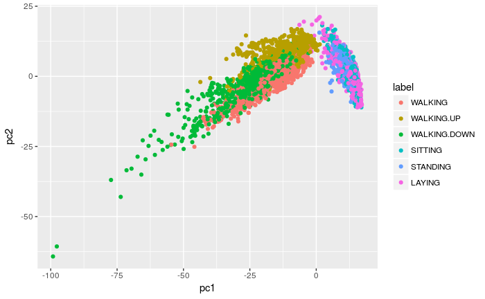

```r
X_tr <- X_full %>% filter(is.train == 1) %>% dplyr::select(-is.train) # Select training data
pca_tr <- prcomp(X_tr) # Get principal components
# Plot
dat_pca <- data.frame(pc1 = pca_tr$x[,1], pc2 = pca_tr$x[,2], pc3 = pca_tr$x[,3],
                      label = as.factor(y_train$label))
levels(dat_pca$label) <- c("WALKING", "WALKING.UP", "WALKING.DOWN", "SITTING", "STANDING", "LAYING")
g0 <- ggplot(data = dat_pca, aes(pc1, pc2)) + geom_point(aes(color = label))
g0
```

It looks like just by using the first principal components, one may be able to differenciate between different activitivies (labels). Specifically, `WALKING`, `WALKING.UP` and `WALKING.DOWN` can be classified almost with a linear decision boundary, while `SITTING`, `STANDING` and `LAYING` are more difficult to classify. Of course, we are looking only into the first principal components which explain the most variance in the data. A larger variance in features (which are kinematic variables) means a larger range of motion, so this behavior is expected. If we were to look at principal components with lower variance, we may actually distinguish the last 3 labels better. In fact, looking at the 4th and 5th principal components, we observe

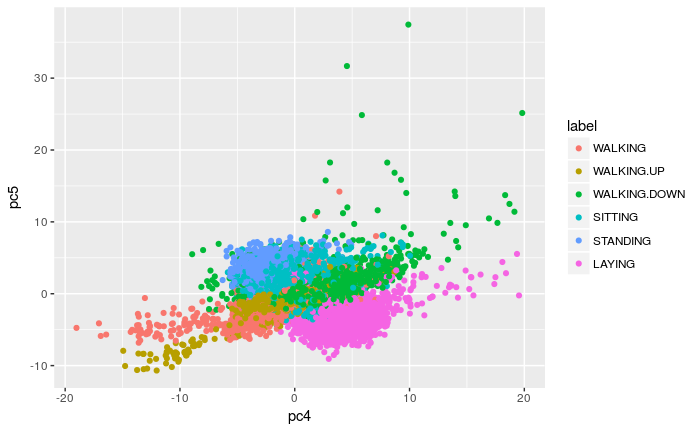

```r
# Plot
dat_pca <- data.frame(pc3 = pca_tr$x[,3], pc4 = pca_tr$x[,4], pc5 = pca_tr$x[,5],
                      label = as.factor(y_train$label))
levels(dat_pca$label) <- c("WALKING", "WALKING.UP", "WALKING.DOWN", "SITTING", "STANDING", "LAYING")
g1 <- ggplot(data = dat_pca, aes(pc4, pc5)) + geom_point(aes(color = label))
g1
```

This looks much better for `SITTING`, `STANDING` and `LAYING`. From this simple investigation, it looks like that linear classifiers may actually do a decent job.

### Gradient Boosting: Tree Booster

The tree booster have a number of hyperparameters that need to be determined using cross-validation (CV). This is performed in the script `train_xgboost.R`. Here, we will use the hyperparameters determined from 5-fold CV. First, we convert the training and testing data into matrices that XGBoost likes to use:

```r
library(xgboost)
# Split back into train/test
X_tr <- X_full %>% filter(is.train == 1) %>% dplyr::select(-is.train)
X_tst <- X_full %>% filter(is.train == 0) %>% dplyr::select(-is.train)
# XGboost wants levels to start with 0
y_tr <- as.factor(y_train$label)
y_tr <- revalue(y_tr, c('6'='5', '5'='4', '4'='3', '3'='2', '2'='1', '1'='0'))
y_tr <- as.numeric(levels(y_tr))[y_tr]
y_tst <- as.factor(y_test$label)
y_tst <- revalue(y_tst, c('6'='5', '5'='4', '4'='3', '3'='2', '2'='1', '1'='0'))
y_tst <- as.numeric(levels(y_tst))[y_tst]
# XGB style matrices
dtrain <- xgb.DMatrix(as.matrix(X_tr), label = y_tr)
dtest <- xgb.DMatrix(as.matrix(X_tst), label = y_tst)
watchlist <- list(train=dtrain, test=dtest)
```

Now, we can fit the tree booster:

```r
# Use best model params
params <- list(booster = "gbtree",
               eval_metric = "mlogloss",
               objective = "multi:softprob",
               eta = 0.50,
               max_depth = 2,
               gamma = 0.0,
               min_child_weight = 0,
               colsample_bytree = 0.2,
               subsample = 1)
modxgb <- xgb.train(params = params,
                    data = dtrain,
                    num_class = 6,
                    nrounds = 499,
                    watchlist = watchlist,
                    verbose = 0) # Change this to 1 to watch the progress
```

Let’s look at the feature importances:

```r
# Importance matrix
importance_matrix <- xgb.importance(model = modxgb) %>%
  mutate(Feature = as.integer(Feature))
top10 <- importance_matrix[1:10, ]$Feature
top10 <- paste0("f", top10)  # Select top 10 fetures from importance
# Names of these features
feat_names_10 <- feat_names %>% filter(code %in% top10) %>%
  mutate(code = substring(code, 2)) %>%
  mutate(code = as.integer(code))
reord <- match(feat_names_10$code, importance_matrix[1:10,]$Feature)
feat_names_10 %>% dplyr::slice(reord)
```

| code | feature |
| --- | --- |
| 279 | fBodyAcc-min()-Y |
| 41 | tGravityAcc-mean()-X |
| 487 | fBodyGyro-bandsEnergy()-1,24 |
| 257 | tBodyGyroJerkMag-min() |
| 486 | fBodyGyro-bandsEnergy()-49,64 |
| 455 | fBodyGyro-skewness()-X |
| 538 | fBodyBodyGyroMag-maxInds |
| 163 | tBodyGyroJerk-mean()-Z |
| 52 | tGravityAcc-max()-Z |
| 71 | tGravityAcc-arCoeff()-Y,2 |

Now, let’s plot the importance as a function of [Gain](http://xgboost.readthedocs.io/en/latest/R-package/discoverYourData.html) in trees split when a specific feature is used.

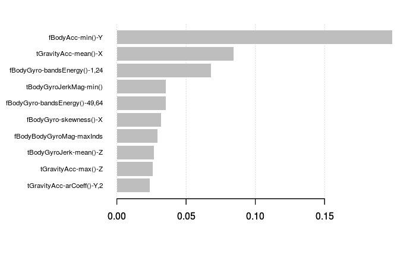

```r
plt.data <- importance_matrix[1:10, ]
plt.data$Feature <- feat_names_10 %>% dplyr::slice(reord) %>% dplyr::select(feature)
xgb.plot.importance(plt.data)
```

Finally, let’s test the model performance on the test set

```r
# Predict
pred_tst <- predict(modxgb, newdata = dtest)
# Reshape in N x n_class
pred_matrix <- matrix(pred_tst, nrow = nrow(X_tst), byrow = TRUE) # Reshape for class probs
# Accuracy
pred_labels <- apply(pred_matrix, 1, which.max)
cat("Accuracy:", sum(pred_labels == y_test$label) / length(y_test$label), "\n")
```

```
Accuracy: 0.9558873
```

```r
# One-hot encoding and multi-class log loss
expanded_tst <- diag(6)
expanded_tst <- t(expanded_tst[, y_test$label])
cat("MLogLoss: ", mlogloss(pred_matrix, expanded_tst), "\n")
```

```
MLogLoss:  0.1376121
```

The confusion matrix provides us information on how well we did for each class:

```r
confusionMatrix(pred_labels, y_test$label)
```

```
Confusion Matrix and Statistics

          Reference
Prediction   1   2   3   4   5   6
         1 487  28   5   0   0   0
         2   9 437  15   2   0   0
         3   0   6 400   0   0   0
         4   0   0   0 443  19   0
         5   0   0   0  46 513   0
         6   0   0   0   0   0 537

Overall Statistics

               Accuracy : 0.9559
                 95% CI : (0.9478, 0.963)
    No Information Rate : 0.1822
    P-Value [Acc > NIR] : < 2.2e-16

                  Kappa : 0.947
 Mcnemar's Test P-Value : NA

Statistics by Class:

                     Class: 1 Class: 2 Class: 3 Class: 4 Class: 5 Class: 6
Sensitivity            0.9819   0.9278   0.9524   0.9022   0.9643   1.0000
Specificity            0.9865   0.9895   0.9976   0.9923   0.9810   1.0000
Pos Pred Value         0.9365   0.9438   0.9852   0.9589   0.9177   1.0000
Neg Pred Value         0.9963   0.9863   0.9921   0.9807   0.9920   1.0000
Prevalence             0.1683   0.1598   0.1425   0.1666   0.1805   0.1822
Detection Rate         0.1653   0.1483   0.1357   0.1503   0.1741   0.1822
Detection Prevalence   0.1765   0.1571   0.1378   0.1568   0.1897   0.1822
Balanced Accuracy      0.9842   0.9587   0.9750   0.9473   0.9726   1.0000
```

### Gradient Boosting: Linear Booster

Similar to the tree booster, the linear booster has a bunch of hyperparameters that need to be determined by CV. This is performed in the script `train_xgboost_linear.R`. Here, we will use the hyperparameters determined from 5-fold CV.

```r
# Use best model params
params <- list(booster = "gblinear",
               eval_metric = "mlogloss",
               objective = "multi:softprob",
               alpha = 0.1,
               lambda = 1,
               eta = 0.3)
modxgb <- xgb.train(params = params,
                    data = dtrain,
                    num_class = 6,
                    nrounds = 497,
                    watchlist = watchlist,
                    verbose = 0) # Change this to 1 to watch the progress
```

Now predict on the test set

```r
# Predict
pred_tst <- predict(modxgb, newdata = dtest)
# Reshape in N x n_class
pred_matrix <- matrix(pred_tst, nrow = nrow(X_tst), byrow = TRUE) # Reshape for class probs
# Accuracy
pred_labels <- apply(pred_matrix, 1, which.max)
cat("Accuracy:", sum(pred_labels == y_test$label) / length(y_test$label), "\n")
```

```
Accuracy: 0.9552087
```

```r
# Multi-class log loss
cat("MLogLoss: ", mlogloss(pred_matrix, expanded_tst), "\n")
```

```
MLogLoss:  0.1331931
```

And the confusion matrix

```r
confusionMatrix(pred_labels, y_test$label)
```

```
Confusion Matrix and Statistics

          Reference
Prediction   1   2   3   4   5   6
         1 492  27   5   0   1   0
         2   0 442  16   3   0   0
         3   4   2 398   0   0   0
         4   0   0   0 432  12   0
         5   0   0   1  55 519   5
         6   0   0   0   1   0 532

Overall Statistics

               Accuracy : 0.9552
                 95% CI : (0.9471, 0.9624)
    No Information Rate : 0.1822
    P-Value [Acc > NIR] : < 2.2e-16

                  Kappa : 0.9462
 Mcnemar's Test P-Value : NA

Statistics by Class:

                     Class: 1 Class: 2 Class: 3 Class: 4 Class: 5 Class: 6
Sensitivity            0.9919   0.9384   0.9476   0.8798   0.9756   0.9907
Specificity            0.9865   0.9923   0.9976   0.9951   0.9747   0.9996
Pos Pred Value         0.9371   0.9588   0.9851   0.9730   0.8948   0.9981
Neg Pred Value         0.9983   0.9883   0.9913   0.9764   0.9945   0.9979
Prevalence             0.1683   0.1598   0.1425   0.1666   0.1805   0.1822
Detection Rate         0.1669   0.1500   0.1351   0.1466   0.1761   0.1805
Detection Prevalence   0.1781   0.1564   0.1371   0.1507   0.1968   0.1809
Balanced Accuracy      0.9892   0.9654   0.9726   0.9375   0.9752   0.9951
```

The results are pretty similar for both boosters.